# IRT Adaptive Testing Analysis

Brian Syzdek

2022-10-15

```r
## Read in a two variable file with ids and new form id, ids called with ids$ITEM_TITLE
ids <- readxl::read_xlsx("new_prov_nascla_exams.xlsx") %>% # Change to be any file
  rename("ITEM_TITLE" = 1)

## Read file (quickly) with all item information (as of Sept. 2022), join with target ids to extract item data for each examination
original_dat <- data.table::fread(file = "C:/Prov/Research/Exams/item_assessment_across_settings/prov_item_exam_date_db.csv") %>%
  inner_join(., ids %>% filter(!duplicated(ITEM_TITLE)), by = "ITEM_TITLE") %>%
  dplyr::select(-form) %>% # drop form number
  filter(CORRECT_FLAG %in% c("N", "Y") &
          # These variables used for filtering minimum counts, so drop if na
          !is.na(TEST_DATE_TIME) &
          !is.na(BLUEPRINT_EXAM_NAME) &
          !is.na(TEST_SESSION_ID)) %>%
  # numeric item response, dates to r dates
  mutate(item_correct_numeric = ifelse(CORRECT_FLAG == "Y", 1, 0),
               date = as.Date(TEST_DATE_TIME),
               year = lubridate::year(date))

# Following is additional data cleaning after reviewing output (described below). Use full_dat throughout analysis. Assigned here to complete all data cleaning here.
full_dat <- original_dat %>%
  filter(!duplicated(.) &
           year >= 2017) %>%
  mutate(ITEM_TITLE = forcats::as_factor(ITEM_TITLE),
         TEST_SESSION_ID = forcats::as_factor(TEST_SESSION_ID)
  ) %>%
  # Remove items with less than 200 responses per exam
  group_by(BLUEPRINT_EXAM_NAME, ITEM_TITLE) %>%
  filter(n_distinct(TEST_SESSION_ID) > 200) %>%
  ungroup
```

# Introduction and Methods

This study will assess use of IRT with an examination. Three new NASCLA examination forms were constructed from items used for similar previous examinations. An IRT assessment paradigm, based on data from past administration of those items, is proposed. The items included in the new NASCLA forms were shown to perform equivalently (have equivalent difficulties) across different forms in which they were included in previously administered examinations (see previous report- Utah Contractor’s Exam) or were similar to those items and considered equivalent. As such, data from administration of those items obtained across forms can be pooled for item analysis for the IRT models (see [Wright](https://www.rasch.org/memo42.htm)).

The approach for utilizing IRT with these items was to first extract individual response data for those items from previous examinations. Items were summarized. With those data, IRT models were constructed and evaluated. An algorithm for administering those items in hypothetical examinations was developed. Simulations were then conducted to compare the IRT model and adaptive algorithm with classical test methods and fixed selection of items.

Two broad approaches were used–a variable-length approach were administration stopped when current ability level was 95% either above or below cut score and a fixed-number format, where a set number of items were administered. Both of these approaches were considered to accommodate different test distribution capabilities. Within both of these approaches, an adaptive IRT approach that sought items near the examinees ability level, a random IRT approach that randomly selected the same number of items as the adaptive approach, and a classical approach that used classical scoring methods with the same number of items were used:

1. Variable Length
1. IRT adaptive (determines number of items)
2. IRT random (same number of items as adaptive)
3. CTT (same number of items as adaptive)
2. Fixed Length (all same set number of items)
1. IRT item-level scoring
2. IRT total-score scoring
3. CTT total-score scoring

Simulations were conducted at varying assumed levels of underlying candidate latent ability. Estimated abilities and pass decisions were then compared for each of the above methods.

Models were assessed by:

1. classification accuracy
2. error
3. closeness to target score
4. number of items needed

This data analysis is generalized to allow for input of any vector of item titles and conduct the above procedures and then output results, as in this report, automatically. (Give specific selection criteria in following) In this particular report, the items are drawn from each of the three exams in turn. Data were queried with completion status complete, items marked correct as either “Y” or “N” (upon inspection found to be mostly redundant with completion status complete), and any date.

# Data Input, Cleaning, and Summary

An overview of the raw data:

```r
# Data head. Use original data to show original count
original_dat %>%
  filter(!duplicated(.)) %>%
  {. -> tmp
  head(tmp) %>%
  table_print(caption = table_counter_func(paste("First 6 records of", nrow(tmp))))
  }
```

*Table* 1: First 6 records of 707298

| TEST SESSION ID | TEST DATE TIME | CORRECT FLAG | ITEM TITLE | BLUEPRINT EXAM NAME | Item Correct Numeric | Date | Year |
| --- | --- | --- | --- | --- | --- | --- | --- |
| 265707 | 2009-03-12 18:02:43 | Y | API0011510 | CustomPMT - SPS - 32 Operator EPCO and KM | 1 | 2009-03-12 | 2009 |
| 270019 | 2009-03-12 17:55:22 | Y | CFT35867 | Industrial Ironworker V2 | 1 | 2009-03-12 | 2009 |
| 269996 | 2009-03-13 17:36:12 | N | API0011510 | Pipeline Maintenance Technician V3 | 0 | 2009-03-13 | 2009 |
| 269968 | 2009-04-08 23:57:02 | Y | CFT35867 | Industrial Ironworker V2 | 1 | 2009-04-08 | 2009 |
| 269889 | 2009-03-17 16:25:12 | N | API0011510 | Pipeline Maintenance Technician V3 | 0 | 2009-03-17 | 2009 |
| 269903 | 2009-03-16 18:12:38 | Y | API0011510 | Pipeline Maintenance Technician V3 | 1 | 2009-03-16 | 2009 |

## Data Validation/Cleaning

Data were examined and cleaned with the following procedures.

### Duplicate Records

Data were examined for duplication across all columns. The following number of duplicates were found and were removed from the data set.

```r
###*** Identify any duplicates
original_dat %>%
  filter(duplicated(.)) %>%
  dplyr::summarise("Number of Duplicates" = nrow(.)) %>%
  table_print(caption = table_counter_func("Duplicates across all fields"))
```

*Table* 2: Duplicates across all fields

| Number of Duplicates |
| --- |
| 0 |

### Items without valid responses

Items with invalid responses for being marked correct (“CORRECT_FLAG”) or those with no response for item title or test date were considered invalid and were filtered from the data. This is confirmed:

```r
full_dat %>%
  filter(! CORRECT_FLAG %in% c("N", "Y"),
         is.na(ITEM_TITLE),
         is.na(TEST_DATE_TIME)) %>%
  dplyr::summarise("Number of Invalid Items" = n()) %>%
  table_print(caption = table_counter_func("Invalid Items"))
```

*Table* 3: Invalid Items

| Number of Invalid Items |
| --- |
| 0 |

### Minimum item counts and recent records

Rasch analysis generally requires at least 100 records of data per item, with higher parameter models needing more. In addition, item data was drawn from different forms from different administrations. Some IRT estimation tools can handle incomplete data, but severely incomplete data can cause estimation problems. A minimum of 200 administrations of an item for each exam that item was draw from was deemed necessary to include data for that item.

In addition, only data from 2017 or later were included, as that interval was examined in previous analysis. After filtering by these conditions, there were 337510 records. There were 157 different items from 53529 separate administrations to individual examinees total.

# IRT Model Construction

```r
###*** Gets persons as rows, items as columns, with 1 as Yes, 0 as No, used in irt, filters out cases incompatible with IRT
person_rows_item_columns_func <- function() {
  full_dat %>%
    dplyr::select(ITEM_TITLE, TEST_SESSION_ID, item_correct_numeric) %>%
    pivot_wider(., names_from = ITEM_TITLE, values_from = item_correct_numeric) %>%
    filter(rowSums(!is.na(.)) > 1) %>%
    dplyr::select(where(~!all(is.na(.x))))
}
```

## Data Suitability for IRT

The data were examined for IRT modeling. First, data were arranged with TEST_SESSION_ID as rows and each level of ITEM_TITLE (individual items) as columns, so each row represented an individual’s responses for target items within one test session. Rows (individuals) with only one level of response (0 or 1) were removed. This resulted in a dataset with 53529 records.

However, because data were gathered from multiple examinations and forms, there were a number of incomplete (NA) values in the data.

```r
person_rows_item_columns_func()[-1] %>%
  pivot_longer(everything(), names_to = "item", values_to = "responses") %>%
  group_by(item, responses) %>%
  summarise(n = n()) %>%
  pivot_wider(everything(), names_from = "item", values_from = "n") %>%
  table_print(., caption = table_counter_func("Item Response Count")) %>%
  scroll_box_func()
```

*Table* 4: Item Response Count

| Responses | API0011510 | ARK100045 | ARK100056 | ARK100056A | ARK100090 | ARK100202 | ARK100215 | ARK100218 | ARK100219 | ARK100335 | ARK100428 | ARK100584 | ARK100585 | ARK100611 | ARK100625A | ARK100629A | ARK100635A | ARK100639A | ARK100645 | ARK100647 | ARK100656 | ARK100660 | ARK100667 | ARK100668 | ARK100671 | ARK100672 | ARK100678 | ARK100683 | ARK100685 | … |
| --- | --- | --- | --- | --- | --- | --- | --- | --- | --- | --- | --- | --- | --- | --- | --- | --- | --- | --- | --- | --- | --- | --- | --- | --- | --- | --- | --- | --- | --- | --- |
| 0 | 566 | 1309 | 97 | 432 | 664 | 886 | 485 | 324 | 988 | 120 | 345 | 1042 | 187 | 970 | 781 | 872 | 438 | 874 | 693 | 1089 | 77 | 291 | 120 | 252 | 174 | 115 | 180 | 152 | 144 | … |
| 1 | 515 | 1726 | 404 | 2868 | 1756 | 1050 | 958 | 2260 | 2482 | 164 | 390 | 889 | 552 | 1246 | 812 | 1629 | 1066 | 654 | 2624 | 1700 | 677 | 321 | 97 | 215 | 272 | 305 | 736 | 613 | 568 | … |
| NA | 52448 | 50494 | 53028 | 50229 | 51109 | 51593 | 52086 | 50945 | 50059 | 53245 | 52794 | 51598 | 52790 | 51313 | 51936 | 51028 | 52025 | 52001 | 50212 | 50740 | 52775 | 52917 | 53312 | 53062 | 53083 | 53109 | 52613 | 52764 | 52817 | … |

## Model Construction

IRT modelling applications can have problems with a large number of NA values or for rows or columns with only one response level, which lead to rank deficiencies in model estimates. Multiple packages and models were considered for IRT modeling, with the MIRT package, using the Rasch (1PL) model, found to construct a suitable model.

However, it was not possible to obtain some typical model diagnostic information, such as model fit statistics, model standard error, or item-fit statistics due to the large percentage of incomplete cases. However, examining the item parameters and plots and overall measure of model reliability, suggested the model would be appropriate.

```r
## Consider other IRT models, non converged except Rasch here
# purrr::map(.x = c("3PL", "2PL", "Rasch"),
#         .f = ~ {
#           mirt::mirt(
#             person_rows_item_columns_func()[-1],
#             1,
#             itemtype = .x,
#             SE = TRUE,
#             verbose = FALSE # suppress iteration results
#           )
#         }) -> irt_mods

## Construct Rasch model from prepared data
rasch_mod <- mirt::mirt(
    person_rows_item_columns_func()[-1],
    1,
    itemtype = "Rasch",
    SE = TRUE,
    verbose = FALSE, # suppress iteration results
    accelerate = 'none'
)

# Parameter scores
nascla_difficulties <- function(){
  mirt::coef(rasch_mod, simplify = TRUE, IRTpars = TRUE)$items %>%
  as.data.frame() %>%
  tibble::rownames_to_column("question_content") %>%
  dplyr::select(question_content, difficulty = b)
}
```

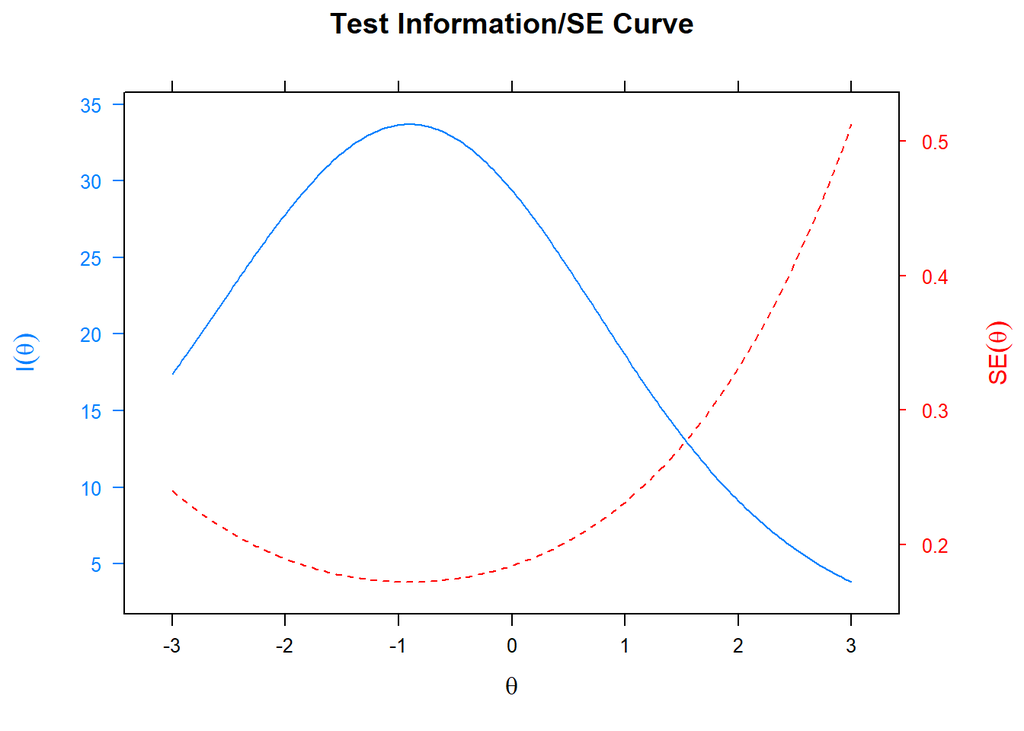

```r
## Fit stats-not calculated here b/c incomplete data
# mirt::M2(rasch_mod, type = "C2", calcNULL = FALSE, na.rm = T)

# Information curve/ SE curve
mirt::plot(rasch_mod, type = 'infoSE', theta_lim = c(-3, 3),
     main="Test Information/SE Curve")
```

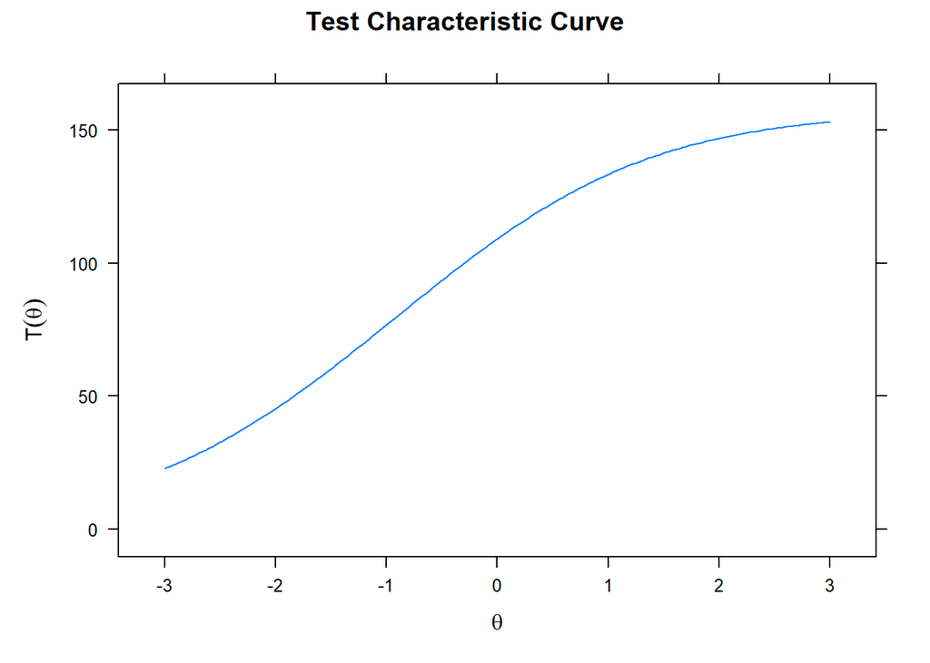

```r
# Test characteristic curve
plot(rasch_mod, type = 'score', theta_lim = c(-3, 3), main = "Test Characteristic Curve")
```

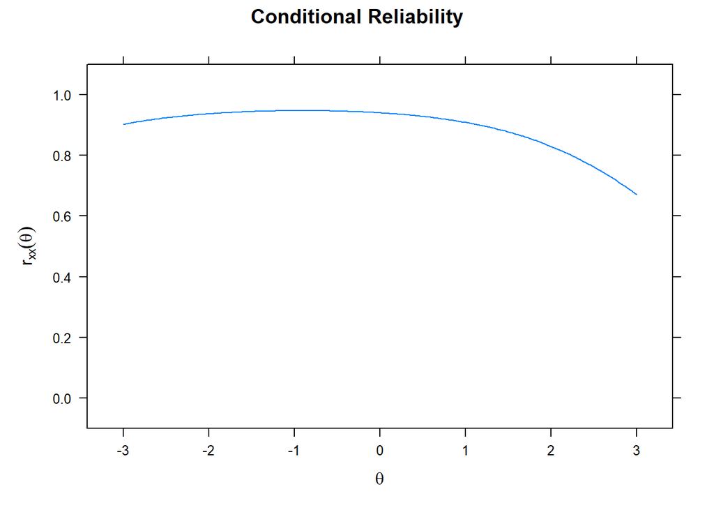

```r
# Plot of reliability across theta- conditional reliability
mirt::plot(rasch_mod, type = 'rxx', theta_lim = c(-3, 3),
     main="Conditional Reliability")
```

```r
# Item loadings onto factor
capture.output(summary(rasch_mod)) -> out
```

The model converged with a marginal reliability of 0.96 and SS Loadings of 24.45. The mean difficulty score was -0.97.

(Interpret) It seems that the model provides maximum information at around ability levels of -1. The model has peak information at that theta value. Items average around that value. It is not surprising as average p-values for all items were 0.68. That is about one standard deviation easier than the mean, similarly represented in the logit scale. For these reasons, -1 will be used as a cut score for simulations below.

## Item Difficulties

Rasch item difficulties, item p-values, and number of times administered are reported.

```r
nascla_difficulties() %>%
  arrange(desc(difficulty)) %>%
  inner_join(.,
             full_dat %>%
               group_by(ITEM_TITLE) %>%
               dplyr::summarise(avg_item_correct = sum(item_correct_numeric)/n(),
                   number_of_administrations = n()
                   ),
             by = c("question_content" = "ITEM_TITLE")) %>%
  mutate(across(where(is.numeric), round, 2)) %>%
  table_print(., caption = table_counter_func("Item Difficulties"), colnames = c("Item", "Rasch Difficulty", "P-value", "Times Administered")) %>%
 scroll_box(width = "600px", height = "500px")
```

*Table* 5: Item Difficulties

| Item | Rasch Difficulty | P-value | Times Administered |
| --- | --- | --- | --- |
| PACFT44016 | 0.83 | 0.33 | 403 |
| ARK105527 | 0.45 | 0.40 | 264 |
| ARK101040 | 0.45 | 0.40 | 2482 |
| ARK101920 | 0.40 | 0.41 | 1483 |
| ARK100983 | 0.35 | 0.43 | 855 |
| ARK101904 | 0.34 | 0.42 | 3739 |
| ARK100639A | 0.34 | 0.43 | 1528 |
| ARK101909 | 0.31 | 0.43 | 2323 |
| ARK101911 | 0.31 | 0.43 | 3018 |
| ARK101907 | 0.27 | 0.44 | 4224 |
| ARK101882 | 0.24 | 0.45 | 2129 |
| ARK100667 | 0.22 | 0.45 | 217 |
| ARK102095 | 0.21 | 0.45 | 247 |
| ARK100977 | 0.21 | 0.45 | 923 |
| ARK100584 | 0.19 | 0.46 | 1931 |
| ARK100830 | 0.18 | 0.46 | 2624 |
| PACFT35973 | 0.17 | 0.46 | 2522 |
| ARK100973A | 0.16 | 0.47 | 3471 |
| ARK100668 | 0.14 | 0.46 | 467 |
| ARK101922 | 0.11 | 0.48 | 658 |
| API0011510 | 0.10 | 0.48 | 1081 |
| ARK100997 | 0.10 | 0.47 | 617 |
| ARK101002A | 0.10 | 0.49 | 611 |
| ARK101916 | 0.09 | 0.48 | 1208 |
| ARK100718A | 0.02 | 0.51 | 258 |
| ARK100625A | -0.02 | 0.51 | 1593 |
| ARK113154 | -0.07 | 0.49 | 976 |
| ARK100847 | -0.11 | 0.52 | 2616 |
| ARK113164 | -0.13 | 0.50 | 3661 |
| ARK100998B | -0.14 | 0.54 | 1140 |

[output cut: 127 more lines]

Inspection of Rasch item difficulties find they correspond to p-values.

# Adaptive Asssessment

An algorithm was devised to efficiently administer items to a hypothetical candidate to determine the candidate’s ability and if the candidate would meet a given cut score (-1). The algorithm also prioritized presenting a diverse array of items to avoid duplicating items.

The algorithm was then tested in hypothetical scenarios to evaluate performance. Candidates were assigned underlying latent abilities (ground truth) and the accuracy of the model in correctly classifying pass decision was calculated and compared with IRT methods with random selection and CTT methods. The simulated scenarios were run multiple times and performance statistics gathered.

## Algorithm Description

Here’s a general description of the algorithm and simulation methods–from the item-bank, a range of items generally within the candidate’s estimated ability level are identified. One item is randomly selected (to increase variety of items administered). The candidate’s response to the item is generated, based on the underlying latent ability and item difficulty. The candidate’s estimated ability level is then updated based on that and previous item responses and the procedure is repeated. Of note, as the standard error becomes less, the range of candidate items becomes smaller and more preceise. In the variable-length simulation conditions, this is repeated until the candidate’s estimated ability level is outside the cut-score ability level, withini 95% CI. In the fixed-length conditions, the procedure is repeated for a specified number of items.

```r
###*** These are user selected values based on desired exam and candidate characteristics to be hand-adjusted
items_per_exam <- 50 # maximum number of items presented
current_candidate_latent_ability <- .5 # Only for coding; is iterated through in simulations below
pass_score <- -1
# Df of difficulties paired with items
irt_model_coefficients <- nascla_difficulties()

###*** Test characteristics of logistic scale
absolute_sd <- 1
absolute_max_score <- max(irt_model_coefficients$difficulty)
absolute_min_score <- min(irt_model_coefficients$difficulty)

###*** Generate 0 or 1 response based on logistic function and candidate ability
###* This will be used for each selected item to generate a response
is_response_correct_func <- function(item_difficulty, current_candidate_latent_ability){
  # rbinom chooses 0 or 1 for given probability
  rbinom(n = 1, size = 1, prob =
           # logistic function solved for P
  exp(1.7*(current_candidate_latent_ability - item_difficulty)) /
    (1 + exp(1.7*(current_candidate_latent_ability - item_difficulty)))
  )
}

###*** Initialize global variables that are used to track data over administration of items
initialize_variables_func <- function(){

# Dataset to track correct and incorrect responses
response_dat <<- tibble()
response_vector <<- tibble()

# This dataset will hold remaining candidate items. As each item is administered it is removed, so as not to duplicate items
filtered_dat <<- irt_model_coefficients

# These hold candidate ability scores and are updated with each response as factor score fed with candidate response vector
  # initialize with this as we want items near pass score and can't know candidate information beforehand
current_score <<- pass_score
current_se <<- absolute_sd

###*** This prepares the first item and removes it from filtered_dat
filtered_dat %>%
  # Get item pool within +/- standard error of candidate current ability
  filter(between(difficulty,
                 current_score - current_se,
                 current_score + current_se)) %>%
  {. -> tmp
    # This step ensures there are items within that range. If not selects closest
    if(nrow(tmp) == 0){
      # Gets closest item
      tmp <- filtered_dat %>%
        slice_min(abs(current_score - difficulty))
    } else{
      # Randomly select item within se range
      tmp <- slice_sample(tmp, n = 1)
    }
    # Hold selected item as current item
    current_item <<- tmp
    # Remove that item from item pool
    filtered_dat <<- filtered_dat %>%
      anti_join(., tmp, by = "question_content")
  }
}

###*** This function gathers administered items, candidate responses, candidate ability estimates, and prepares next question based on current ability
select_next_question_func<- function(points_to_add){

# Holds all responses, will add 0 or 1 based on correct or incorrect response, determined when this function is applied
response_dat <<- bind_rows(response_dat, # add new item as row
                           current_item %>%
                             dplyr::select(-difficulty) %>%
                             mutate(points = points_to_add)
                           )

###*** Join all responses with data that holds irt parameters. Will order responses in same order as rasch coefficients to input response vector
response_vector <<- left_join(irt_model_coefficients,
                             response_dat,
                             by = "question_content"
                             )

# Get current score and se at each administration of items
current_score <<- mirt::fscores(rasch_mod,
                                response.pattern = response_vector$points)[1]

current_se <<- mirt::fscores(rasch_mod,
                             response.pattern = response_vector$points)[2]

###*** filtered_dat is unused item pool. From it new item is chosen based on candidate current ability, within range of se. Items randomly selected within that interval for administration variety
filtered_dat %>%
  # Get item pool within +/- standard error of candidate current ability
  filter(between(difficulty,
                 current_score - current_se,
                 current_score + current_se)) %>%
  {. -> tmp
    # This step ensures there are items within that range. If not selects closest
    if(nrow(tmp) == 0){
      # Gets closest item
      tmp <- filtered_dat %>%
        slice_min(abs(current_score - difficulty))
    } else{
      # Randomly select item within se range
      tmp <- slice_sample(tmp, n = 1)
    }
    # Hold selected item as current item
    current_item <<- tmp
    # Remove that item from item pool
    filtered_dat <<- filtered_dat %>%
      anti_join(., tmp, by = "question_content")
  }
}

###*** Function first checks to see if candidate within standard error of pass_score. If outside that range, a decision can be made about passing and no more items administered. If within range, administers current item, determines if correct response, based on candidate ability and item difficulty, then prepares next item
item_selector_func <- function(current_candidate_latent_ability){
  # If current store within standard error of cut score, administer more questions, else stop
  if(between(pass_score,
             current_score - 1.96*current_se,
             current_score + 1.96*current_se)
     ){
    # Determine if a correct response, then add item with point (1) or (0)
    select_next_question_func(is_response_correct_func(current_item$difficulty, current_candidate_latent_ability))
  }
}
```

```r
###*** Apply above functions to "administer test"
# Administer across different underlying ability conditions
purrr::map(
  .x = seq(-2, 1, .5), # Different latent abilities
  .f = function(current_candidate_latent_ability){ # list for each ability
purrr::map_dfr(1:50,~{ # Times to administer each exam
    # Reset all holder variables
    initialize_variables_func()
    # Administer each exam. items_per_exam is max number of items per exam
    replicate(items_per_exam, item_selector_func(current_candidate_latent_ability) -> tmp) # tmp suppresses output
    # Get summary of each exam
    as.data.frame(tibble(
      # Z-score of number correct
      number_items_administered = nrow(response_dat),
      # Given items candidate responded to, how many should be correct?
      expected_items_correct = expected.test(rasch_mod,
                                             Theta =
                                          matrix(current_candidate_latent_ability),
                                             which.items =
                                            which(!is.na(response_vector$points))),
      # Number of items correct
      actual_items_correct = sum(response_dat$points, na.rm = TRUE),
      # Current candidate ability score
      candidate_ability_estimate = current_score,
      # Current standard error
      ability_estimate_se = current_se,
      # z score of number correct/number administered
      z_score_ctt = (sum(response_dat$points)/nrow(response_dat)) %>%
               qnorm(, mean = 0, sd = 1)
    )) %>%
      # Taking a random sample of the same number of items administered in adaptive testing, what is the irt ability score and se?
    bind_cols(.,
              # Calculate probability of success and evaluate success based on this
              response_vector %>%
                rowwise() %>%
                mutate(
                  # Probability of success
                  person_item_probability =
                    exp(1.7*(current_candidate_latent_ability - difficulty)) /
               (1 + exp(1.7*(current_candidate_latent_ability - difficulty))),
                  # Random success or not
                  expected_response = is_response_correct_func(difficulty,
                                                current_candidate_latent_ability)
               ) %>%
    ungroup %>%
      # From those calculated successes, take a sample of the same size as items administered, replace rest with NA
    mutate(expected_response =  replace(expected_response,
                                    # Sample row numbers of unadminstered item size
                                        sample(row_number(),
                                               size = (
                                                 nrow(response_vector) -
                                                   nrow(response_dat)
                                                 ),
                                               replace = FALSE), NA)
           ) %$%
      # Get factor score from this sampled vector
    fscores(rasch_mod, response.pattern = .$expected_response) %>%
      as.data.frame() %>%
      rename("fixed_items_ability" = "F1",
             "fixed_items_SE" = "SE_F1")
    ) %>% # End bind_cols
      mutate(
        items_administered = list(tibble(items = response_dat$question_content))
        )
    })  %>% # End map- the administration of all forms
  mutate(across(where(is.numeric), round, 2)) %>%
  rowwise() %>%
  mutate(
    z_score_ctt = case_when(
      identical(z_score_ctt, Inf) ~ 3,
      identical(z_score_ctt, -Inf) ~ -3,
      TRUE ~ z_score_ctt),
    decision = case_when(
      candidate_ability_estimate < pass_score & current_candidate_latent_ability < pass_score ~ "true_fail",
      candidate_ability_estimate > pass_score & current_candidate_latent_ability > pass_score ~ "true_pass",
      candidate_ability_estimate < pass_score & current_candidate_latent_ability > pass_score ~ "false_fail",
      candidate_ability_estimate > pass_score & current_candidate_latent_ability < pass_score ~ "false_pass",
      TRUE ~ "inconclusive"
    ), .before = 1
  ) %>%
  ungroup
}) %>%
  purrr::set_names(seq(-2, 1, .5)) -> sim_dat
```

# Simulation Results

Simulations were conducted with the algorithm and models. First the adpative algorithm was run 50 times each for assumed underlying candidate latent ability levels of -2 to 1 by .5. The algorithm stopped when a 95% CI decision could be made about pass/fail. The adaptive condition, along with IRT and CTT random selection of (the same number) of administered items, and resulting outcomes were considered.

## Data Overview

```r
###*** Overview of output. Choose element of list far from cut score to get few items
sim_dat[[7]] %>%
  table_print(., caption = table_counter_func(paste("Simulation Output for Latent Ability", names(sim_dat)[7]))) %>%
  scroll_box(width = "800px", height = "500px")
```

*Table* 6: Simulation Output for Latent Ability 1

| Decision | Number Items Administered | Expected Items Correct | Actual Items Correct | Candidate Ability Estimate | Ability Estimate Se | z Score Ctt | Fixed Items Ability | Fixed Items SE | Items Administered |
| --- | --- | --- | --- | --- | --- | --- | --- | --- | --- |
| true_pass | 3 | 2.42 | 3 | 0.47 | 0.65 | 3.00 | 0.41 | 0.65 | ARK113111, ARK100045, ARK101882 |
| true_pass | 2 | 1.54 | 2 | 0.39 | 0.66 | 3.00 | -0.13 | 0.67 | ARK100726, ARK100830 |
| true_pass | 2 | 1.59 | 2 | 0.36 | 0.66 | 3.00 | 0.28 | 0.69 | ARK102066 , ARK100718A |
| true_pass | 2 | 1.56 | 2 | 0.37 | 0.66 | 3.00 | 0.18 | 0.69 | ARK106336, ARK100668 |
| true_pass | 2 | 1.58 | 2 | 0.37 | 0.66 | 3.00 | 0.43 | 0.66 | ARK100045, ARK100611 |
| true_pass | 3 | 2.44 | 3 | 0.47 | 0.64 | 3.00 | 0.32 | 0.66 | ARK102209, ARK101720, ARK100428 |
| true_pass | 2 | 1.65 | 2 | 0.32 | 0.67 | 3.00 | 0.23 | 0.68 | PACFT32535, ARK100718A |
| true_pass | 2 | 1.54 | 2 | 0.38 | 0.66 | 3.00 | 0.35 | 0.66 | ARK100726 , PACFT35973 |
| true_pass | 2 | 1.58 | 2 | 0.36 | 0.67 | 3.00 | 0.35 | 0.67 | PACFT49456, ARK101882 |
| true_pass | 2 | 1.60 | 2 | 0.35 | 0.67 | 3.00 | 0.23 | 0.68 | ARK105536, ARK102095 |
| true_pass | 2 | 1.51 | 2 | 0.40 | 0.66 | 3.00 | 0.36 | 0.67 | ARK100728, ARK101920 |
| true_pass | 4 | 3.06 | 3 | 0.29 | 0.61 | 0.67 | 0.34 | 0.65 | ARK100585 , ARK100998B, ARK100584 , ARK101002A |
| true_pass | 2 | 1.51 | 2 | 0.40 | 0.66 | 3.00 | 0.22 | 0.68 | PACFT42714, ARK100668 |
| true_pass | 2 | 1.66 | 2 | 0.33 | 0.67 | 3.00 | 0.35 | 0.67 | ARK100726 , PACFT42714 |
| true_pass | 2 | 1.64 | 2 | 0.34 | 0.66 | 3.00 | 0.32 | 0.68 | PACFT49505, PACFT42714 |
| true_pass | 3 | 2.44 | 3 | 0.46 | 0.65 | 3.00 | 0.39 | 0.65 | ARK101330 , ARK100851 , ARK100973A |
| true_pass | 2 | 1.67 | 2 | 0.32 | 0.67 | 3.00 | 0.32 | 0.67 | ARK108265, ARK100809 |
| true_pass | 3 | 2.43 | 3 | 0.46 | 0.65 | 3.00 | 0.42 | 0.65 | PACFT41241, ARK100810 , ARK100983 |
| true_pass | 2 | 1.61 | 2 | 0.33 | 0.68 | 3.00 | 0.31 | 0.67 | PACFT32726, ARK101904 |
| true_pass | 4 | 3.10 | 3 | 0.27 | 0.61 | 0.67 | 0.24 | 0.61 | ARK101918 , ARK101920 , PACFT0040010, ARK100998B |
| true_pass | 2 | 1.60 | 2 | 0.35 | 0.67 | 3.00 | 0.27 | 0.67 | PACFT0040004A, ARK100973A |
| true_pass | 12 | 9.60 | 7 | -0.05 | 0.47 | 0.21 | 0.97 | 0.56 | ARK102087 , ARK101002A, ARK100584 , PACFT48123, ARK100660 , ARK101004A, ARK100611 , CFT36872 , ARK100219 , ARK100215 , ARK113154 , ARK113164 |
| true_pass | 7 | 5.26 | 4 | 0.07 | 0.54 | 0.18 | 0.78 | 0.59 | ARK100720 , ARK100977 , ARK100805A, ARK101920 , ARK101882 , ARK100428 , ARK108268 |
| true_pass | 2 | 1.64 | 2 | 0.33 | 0.67 | 3.00 | -0.13 | 0.67 | ARK100811A, ARK100847 |
| true_pass | 3 | 2.47 | 3 | 0.44 | 0.65 | 3.00 | 0.30 | 0.67 | ARK101330 , ARK100625A, ARK100851 |
| true_pass | 4 | 3.16 | 3 | 0.25 | 0.61 | 0.67 | 0.40 | 0.64 | ARK100837 , ARK100629A, ARK100428 , ARK101896 |
| true_pass | 3 | 2.53 | 3 | 0.41 | 0.65 | 3.00 | 0.36 | 0.65 | PACFT49810, ARK106205 , ARK101723 |
| true_pass | 2 | 1.59 | 2 | 0.36 | 0.66 | 3.00 | 0.24 | 0.68 | ARK101004A, ARK100202 |
| true_pass | 2 | 1.41 | 2 | 0.45 | 0.66 | 3.00 | 0.20 | 0.68 | ARK100847, ARK100983 |
| true_pass | 2 | 1.58 | 2 | 0.37 | 0.66 | 3.00 | 0.33 | 0.67 | ARK108268, ARK100335 |
| true_pass | 2 | 1.57 | 2 | 0.36 | 0.67 | 3.00 | 0.16 | 0.69 | CFT36872 , ARK100977 |
| true_pass | 2 | 1.54 | 2 | 0.39 | 0.66 | 3.00 | -0.35 | 0.68 | ARK113164, ARK101723 |
| true_pass | 2 | 1.62 | 2 | 0.33 | 0.67 | 3.00 | 0.16 | 0.69 | ARK110813, ARK100667 |
| true_pass | 6 | 4.79 | 4 | 0.14 | 0.56 | 0.43 | 0.24 | 0.60 | ARK102061 , ARK101720 , PACFT48123, ARK100851 , ARK101004A, ARK101002A |
| true_pass | 4 | 3.17 | 3 | 0.23 | 0.61 | 0.67 | 0.11 | 0.63 | ARK113111 , ARK100611 , ARK100625A, ARK100997 |
| true_pass | 2 | 1.60 | 2 | 0.34 | 0.67 | 3.00 | 0.23 | 0.68 | ARK101316, ARK101882 |
| true_pass | 2 | 1.58 | 2 | 0.36 | 0.67 | 3.00 | -0.12 | 0.67 | ARK113146, ARK100668 |
| true_pass | 2 | 1.61 | 2 | 0.34 | 0.67 | 3.00 | 0.28 | 0.67 | PACFT0040004A, ARK101002A |
| true_pass | 2 | 1.48 | 2 | 0.42 | 0.66 | 3.00 | 0.29 | 0.67 | ARK100810 , ARK100639A |
| true_pass | 4 | 3.03 | 3 | 0.30 | 0.61 | 0.67 | 0.51 | 0.63 | ARK108265, ARK100977, ARK101909, ARK100045 |
| true_pass | 2 | 1.54 | 2 | 0.39 | 0.66 | 3.00 | 0.16 | 0.69 | PACFT49824, ARK100830 |
| true_pass | 2 | 1.67 | 2 | 0.32 | 0.67 | 3.00 | 0.23 | 0.68 | ARK101039, ARK100809 |
| true_pass | 2 | 1.59 | 2 | 0.36 | 0.67 | 3.00 | 0.16 | 0.69 | ARK110072 , API0011510 |
| true_pass | 2 | 1.56 | 2 | 0.37 | 0.66 | 3.00 | -0.01 | 0.66 | ARK101039, ARK100584 |
| true_pass | 2 | 1.50 | 2 | 0.41 | 0.66 | 3.00 | -0.23 | 0.67 | PACFT41068, ARK101916 |
| true_pass | 5 | 3.55 | 3 | 0.20 | 0.58 | 0.25 | 0.61 | 0.62 | ARK100851, ARK106205, ARK100983, ARK101040, ARK101911 |
| true_pass | 2 | 1.57 | 2 | 0.37 | 0.66 | 3.00 | 0.21 | 0.68 | PACFT0040010, ARK113154 |
| true_pass | 3 | 2.42 | 3 | 0.47 | 0.64 | 3.00 | 0.33 | 0.66 | ARK113115 , ARK100625A, ARK113164 |
| true_pass | 3 | 2.50 | 3 | 0.43 | 0.65 | 3.00 | 0.50 | 0.64 | ARK100678, ARK101896, ARK101914 |
| true_pass | 2 | 1.58 | 2 | 0.37 | 0.66 | 3.00 | 0.16 | 0.69 | ARK100837, ARK100809 |

## Variable-Length

### Classification Accuracy

```r
purrr::imap(
    .x = sim_dat,
    .f = ~ .x %>%
        group_by(decision) %>%
        count %>%
        ungroup() %>%
        mutate(
            theta = .y
        )
) %>%
    bind_rows %>%
    pivot_wider(names_from = decision, values_from = n) %>%
  table_print(., caption = "Decision Accuracy Adaptive Administration")
```

Decision Accuracy Adaptive Administration

| Theta | True Fail | False Pass | Inconclusive | True Pass |
| --- | --- | --- | --- | --- |
| -2 | 50 | NA | NA | NA |
| -1.5 | 49 | 1 | NA | NA |
| -1 | NA | NA | 50 | NA |
| -0.5 | NA | NA | NA | 50 |
| 0 | NA | NA | NA | 50 |
| 0.5 | NA | NA | NA | 50 |
| 1 | NA | NA | NA | 50 |

```r
purrr::map2(
  .x = sim_dat,
  .y = seq(-2, 1, .5),
  .f = ~ .x %>%
    rowwise() %>%
    mutate(
      fixed_decision = case_when(
      fixed_items_ability + 1.96*fixed_items_SE < pass_score & .y < pass_score ~ "true_fail",
      fixed_items_ability - 1.96*fixed_items_SE > pass_score & .y > pass_score ~ "true_pass",
      fixed_items_ability + 1.96*fixed_items_SE < pass_score & .y > pass_score ~ "false_fail",
      fixed_items_ability - 1.96*fixed_items_SE > pass_score & .y < pass_score ~ "false_pass",
      TRUE ~ "inconclusive"
      )
    ) %>%
    group_by(fixed_decision) %>%
        count %>%
        ungroup() %>%
        mutate(
            theta = .y
        )
) %>%
    bind_rows %>%
    pivot_wider(names_from = fixed_decision, values_from = n) %>%
  table_print(., caption = "Decision Accuracy Fixed Administration")
```

Decision Accuracy Fixed Administration

| Theta | Inconclusive | True Fail | True Pass |
| --- | --- | --- | --- |
| -2.0 | 33 | 17 | NA |
| -1.5 | 32 | 18 | NA |
| -1.0 | 50 | NA | NA |
| -0.5 | 25 | NA | 25 |
| 0.0 | 28 | NA | 22 |
| 0.5 | 19 | NA | 31 |
| 1.0 | 28 | NA | 22 |

```r
purrr::map2(
  .x = sim_dat,
  .y = seq(-2, 1, .5),
  .f = ~ .x %>%
    rowwise() %>%
    mutate(
      fixed_decision = case_when(
      z_score_ctt + 1.96*fixed_items_SE < pass_score & .y < pass_score ~ "true_fail",
      z_score_ctt  - 1.96*fixed_items_SE > pass_score & .y > pass_score ~ "true_pass",
      z_score_ctt  + 1.96*fixed_items_SE < pass_score & .y > pass_score ~ "false_fail",
      z_score_ctt  - 1.96*fixed_items_SE > pass_score & .y < pass_score ~ "false_pass",
      TRUE ~ "inconclusive"
      )
    ) %>%
    group_by(fixed_decision) %>%
        count %>%
        ungroup() %>%
        mutate(
            theta = .y
        )
) %>%
    bind_rows %>%
    pivot_wider(names_from = fixed_decision, values_from = n) %>%
  table_print(., caption = "Decision Accuracy CTT")
```

Decision Accuracy CTT

| Theta | False Pass | Inconclusive | True Fail | True Pass |
| --- | --- | --- | --- | --- |
| -2.0 | 1 | 47 | 2 | NA |
| -1.5 | 31 | 19 | NA | NA |
| -1.0 | NA | 50 | NA | NA |
| -0.5 | NA | NA | NA | 50 |
| 0.0 | NA | 1 | NA | 49 |
| 0.5 | NA | 3 | NA | 47 |
| 1.0 | NA | NA | NA | 50 |

The above tables show pass/fail classification decisions by method.

### Estimated Ability Deviation from Latent Ability

```r
###*** Calculate the estimated ability and deviation from latent ability and summarize
purrr::imap_dfr(
  .x = sim_dat, # data after running simulation
  .f = ~ .x %>%
    # Subtract latent ability from estimates, absolute value
    mutate(
      theta = as.numeric(.y),
      adaptive_difference = abs(candidate_ability_estimate - theta),
      fixed_difference = abs(fixed_items_ability - theta),
      ctt_difference = abs(z_score_ctt - theta)
      )
) %>%
  bind_rows %>%
  # Mean deviations and SE
  summarise(
    adaptive_mean_difference_from_ability = mean(adaptive_difference),
    adaptive_irt_se_mean = mean(ability_estimate_se),
    fixed_mean_difference_from_ability = mean(fixed_difference),
    fixed_irt_se_mean = mean(fixed_items_SE),
    ctt_mean_difference_from_ability = mean(ctt_difference)
  ) %>%
  mutate(across(where(is.numeric), round, 2)) %>%
  table_print(., caption = table_counter_func("Ability Estimate Deviation from Latent Ability"))
```

*Table* 7: Ability Estimate Deviation from Latent Ability

| Adaptive Mean Difference from Ability | Adaptive Irt Se Mean | Fixed Mean Difference from Ability | Fixed Irt Se Mean | Ctt Mean Difference from Ability |
| --- | --- | --- | --- | --- |
| 0.32 | 0.47 | 0.36 | 0.49 | 1.25 |

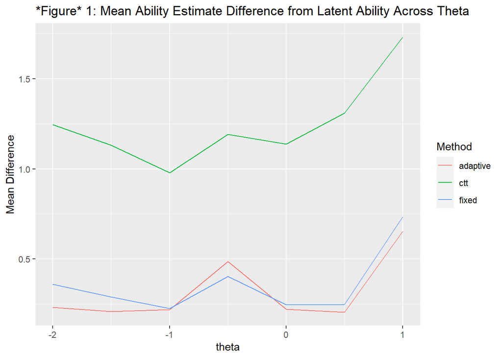

```r
###*** Plot deviation by method and across latent ability

purrr::imap_dfr(
  .x = sim_dat,
  .f = ~ .x %>%
    # Get deviations, then summarize
    mutate(
      theta = as.numeric(.y),
      adaptive_difference = abs(candidate_ability_estimate - theta),
      fixed_difference = abs(fixed_items_ability - theta),
      ctt_difference = abs(z_score_ctt - theta)
      ) %>%
    summarise(
      theta = as.numeric(.y),
      adaptive_mean_difference_from_ability = mean(adaptive_difference),
      adaptive_irt_se_mean = mean(ability_estimate_se),
      fixed_mean_difference_from_ability = mean(fixed_difference),
      fixed_irt_se_mean = mean(fixed_items_SE),
      ctt_mean_difference_from_ability = mean(ctt_difference)
    )
  ) %>%
  bind_rows %>%
  dplyr::select(theta, adaptive = adaptive_mean_difference_from_ability, fixed = fixed_mean_difference_from_ability, ctt = ctt_mean_difference_from_ability) %>%
  pivot_longer(-theta, names_to = "Method", values_to = "Mean Difference") %>%
  ggplot(., aes(x = theta, y = `Mean Difference`, color = Method)) +
  geom_line() +
  ggtitle(figure_counter_func("Mean Ability Estimate Difference from Latent Ability Across Theta"))
```

### Item Variety

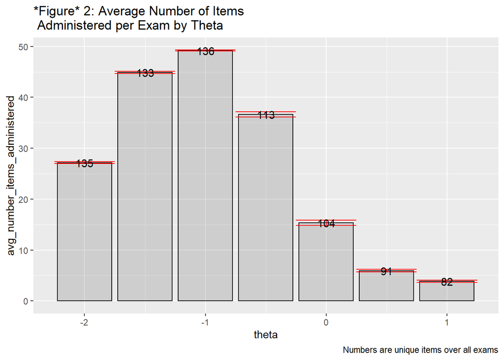

```r
###*** Get counts of unique items administered as measure of presenting diverse items
purrr::imap_dfr(
  .x = sim_dat,
  .f = ~ .x %>%
    rowwise() %>%
    mutate(
      number_items_administered = items_administered %>% unlist %>% length
      ) %>%
    ungroup() %>%
    unnest_longer(col = items_administered) %>%
    summarise(
      theta = as.numeric(.y),
      avg_number_items_administered = mean(number_items_administered),
      sem = psych::describe(number_items_administered)$se,
      n = sum(!duplicated(items_administered$items))
    )
  ) %>%
  bind_rows %>%
  # Plot average deviations by method, across theta
  ggplot(., aes(x = theta, y = avg_number_items_administered, label = n)) +
  # Bar plot
  geom_col(
                          position = position_dodge2(preserve = "single"),
                          alpha = 0.2,
                          color = "black"
                        ) +
          # Errorbars of sem
              geom_errorbar(aes(ymin = avg_number_items_administered - sem, ymax = avg_number_items_administered + sem), position = position_dodge(width=0.9), color = "red", width = 0.5) +
  # Number of unique items
  geom_text(hjust = .5) +
  ggtitle(figure_counter_func("Average Number of Items \n Administered per Exam by Theta")) +
  labs(caption = "Numbers are unique items over all exams")
```

## Fixed Length

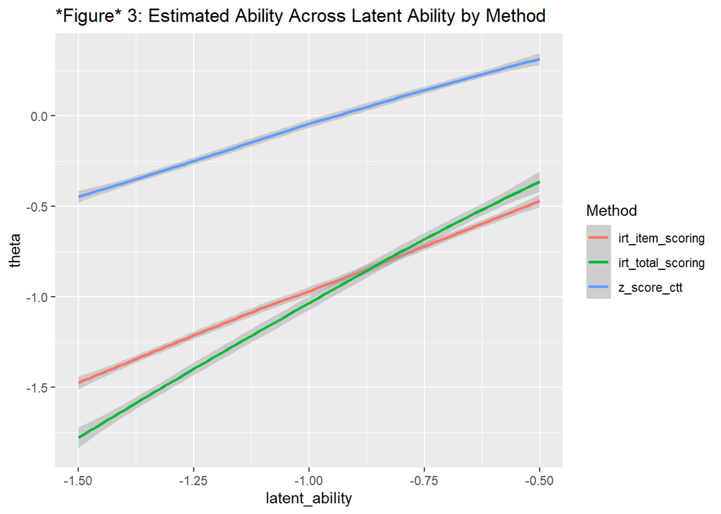

```r
fixed_sim_dat <- purrr::map_dfr(
  .x = seq(-1.5, -.5, .1), # Underlying ability estimates
  .f = ~{
  current_candidate_latent_ability <- .x
  # Administer adaptive model
  purrr::map_dfr(1:50,~{ # Times to administer each exam
    # Reset all holder variables
    initialize_variables_func()
    # Administer each exam. items_per_exam is max number of items per exam
    items_per_exam = 75
    replicate(items_per_exam,
              select_next_question_func(
      is_response_correct_func(current_item$difficulty,
                        current_candidate_latent_ability)) -> tmp)

    ## Df of all items and difficulties and probabilities of correct, with assumed response, to be sampled for total score and ctt
total_correct_sample <- response_vector %>%
  rowwise() %>%
  mutate(
    # Probability of success
    person_item_probability =
      exp(1.7*(current_candidate_latent_ability - difficulty)) /
      (1 + exp(1.7*(current_candidate_latent_ability - difficulty))),
    # Random success or not
    expected_response = is_response_correct_func(
      difficulty,
      current_candidate_latent_ability)
      ) %>%
    ungroup %>%
      # From those calculated successes, take a sample of the same size as items administered, replace rest with NA
    mutate(
      expected_response = replace(expected_response,
        # Sample row numbers of unadminstered item size
        sample(row_number(),
               size = (nrow(response_vector) - nrow(response_dat)),
               replace = FALSE), NA)
           )
# Total correct from random selection of items
sum_correct_fixed <- total_correct_sample %>%
  summarise(total_correct = sum(expected_response, na.rm = TRUE)) %>%
  dplyr::select(total_correct) %>% pull

# Total scores and accompanying thetas for items selected
fixed_exam_theta <- tibble(
      theta = seq(-3,3,.1),
      score = expected.test(
        rasch_mod,
        Theta = matrix(seq(-3,3,.1)),
        which.items = which(!is.na(total_correct_sample$expected_response))
      )
    ) %>%
  rowwise() %>%
  # Subtract each score from the candidate score
  mutate(
    score_difference = abs(score - sum_correct_fixed)
  ) %>%
  ungroup %>%
  # Fine closest score and get accompanying theta
  slice_min(score_difference) %>%
  dplyr::select(theta) %>% pull

    tibble(
      adaptive_exam_theta = mirt::fscores(rasch_mod,
                      response.pattern = response_vector$points)[1],
      adaptive_exam_se = mirt::fscores(rasch_mod,
                    response.pattern = response_vector$points)[2],
      fixed_exam_theta,
      latent_ability = current_candidate_latent_ability,
      z_score_ctt = (sum_correct_fixed/items_per_exam) %>%
        qnorm(, mean = 0, sd = 1)
    )
}) %>%
    # Correct for when all items answered correctly or incorrectly, assign extreme z
    mutate(
      z_score_ctt = case_when(
      identical(z_score_ctt, Inf) ~ 3,
      identical(z_score_ctt, -Inf) ~ -3,
      TRUE ~ z_score_ctt),
      latent_ability = .x) %>%
    rowwise() %>%
    # Get decision accuracies
    mutate(
      adaptive_decision = case_when(
      adaptive_exam_theta + 1.96*adaptive_exam_se < pass_score & .x < pass_score ~ "true_fail",
      adaptive_exam_theta - 1.96*adaptive_exam_se > pass_score & .x > pass_score ~ "true_pass",
      adaptive_exam_theta + 1.96*adaptive_exam_se < pass_score & .x > pass_score ~ "false_fail",
      adaptive_exam_theta - 1.96*adaptive_exam_se > pass_score & .x < pass_score ~ "false_pass",
      TRUE ~ "inconclusive"
      ),
      fixed_decision = case_when(
      fixed_exam_theta + 1.96*adaptive_exam_se < pass_score & .x < pass_score ~ "true_fail",
      fixed_exam_theta - 1.96*adaptive_exam_se > pass_score & .x > pass_score ~ "true_pass",
      fixed_exam_theta + 1.96*adaptive_exam_se < pass_score & .x > pass_score ~ "false_fail",
      fixed_exam_theta - 1.96*adaptive_exam_se > pass_score & .x < pass_score ~ "false_pass",
      TRUE ~ "inconclusive"
      ),
      ctt_decision = case_when(
      z_score_ctt + 1.96*adaptive_exam_se < pass_score & .x < pass_score ~ "true_fail",
      z_score_ctt  - 1.96*adaptive_exam_se > pass_score & .x > pass_score ~ "true_pass",
      z_score_ctt  + 1.96*adaptive_exam_se < pass_score & .x > pass_score ~ "false_fail",
      z_score_ctt  - 1.96*adaptive_exam_se > pass_score & .x < pass_score ~ "false_pass",
      TRUE ~ "inconclusive"
      )
    ) %>%
    ungroup
  })

###*** Plot of methods across theta
fixed_sim_dat %>%
  bind_rows %>%
  dplyr::select(irt_item_scoring = adaptive_exam_theta, irt_total_scoring = fixed_exam_theta, z_score_ctt, latent_ability) %>%
  pivot_longer(-latent_ability, names_to = "Method", values_to = "theta") %>%
  ggplot(., aes(x = latent_ability, y = theta, color = Method)) +
  geom_smooth() +
  ggtitle(figure_counter_func("Estimated Ability Across Latent Ability by Method"))
```

```r
###*** Table of decisions
fixed_sim_dat %>%
  dplyr::select(irt_item_scoring = adaptive_decision, irt_total_scoring = fixed_decision, z_score_ctt = ctt_decision) %>%
  pivot_longer(everything(), names_to = "Method", values_to = "Decision") %>%
  group_by(Method, Decision) %>%
    count %>%
    ungroup() %>%
  pivot_wider(everything(), names_from = Decision, values_from = n) %>%
  mutate(Method = pretty_columns_func(Method)) %>%
  table_print(., caption = table_counter_func("Fixed Form Decision Accuracy Comparison"))
```

*Table* 8: Fixed Form Decision Accuracy Comparison

| Method | Inconclusive | True Fail | True Pass | False Pass |
| --- | --- | --- | --- | --- |
| Irt Item Scoring | 420 | 53 | 77 | NA |
| Irt Total Scoring | 322 | 129 | 98 | 1 |
| z Score Ctt | 64 | NA | 250 | 236 |

# Discussion

This analysis demonstrated how to use IRT model estimation with a given group of items. As noted, data were not ideal for IRT analysis, due to NA values across administration. Data were cleaned to make more appropriate. A Rasch model was found useful for estimating item difficulties and had meaningful and solid metrics for use in a credentialing scenario. An algorithm for adaptive administration of the model was constructed.

Simulations were run to evaluate the model and algorithm under different conditions. The adaptive IRT model was efficient. It used the minimal number of items necessary to confidently assess candidate pass/fail decisions. It was extremely accurate in those decisions with respect to what should be expected given assumed underlying abilities. An IRT model that randomly selected the same number of items was less efficient when using the same number of items as the adaptive method. It would have benefitted from additional item assessment. Nonetheless, it would be useful and was closely accurate to the adaptive method. The CTT method was less accurate.

A fixed-length form was assumed. Scoring the model by items with IRT, scoring with total scores with IRT, and total scores with CTT were evaluated. The item-level model was more accurate across latent abilities. The total score method was slightly less accurate but was comparably accurate at cut-score ability levels. The CTT method gave inflated scores.

Taken together, an IRT adaptive paradigm would be the most accurate and valid method. IRT methods that scored by random selection, but used item-level data would also be beneficial but would require some additional items. The drawbacks to using these methods would be that the system would require IRT score conversion methods, which may be impractical. To address that IRT methods using a fixed-length form were considered. IRT methods that scored by items were superior. IRT methods that scored by total scores were very close. These methods could be more easily implemented in a system without IRT estimation and scoring capabilities. A number of forms with set items and scores based on those responses could be constructed. Using total scores for those set items could be easily implemented for paper or computer administration.

## To-do

1. Evaluate models with different data
2. Explore practical considerations for implementing